# Multiterminal scattering protected by Fermi surface topology

[figure not shown]

[figure not shown]

[figure not shown]

[figure not shown]

## Multiterminal scattering protected by Fermi surface topology

**Isidora Araya Day**, Kostas Vilkelis, Antonio Manesco, Mert Bozkurt, Valla Fatemi, Anton Akhmerov

[figure not shown]

[figure not shown]

**arxiv:2311.17160**

# Multiterminal scattering protected by Fermi surface topology

## Multiterminal scattering protected by Fermi surface topology

**Isidora Araya Day**, Kostas Vilkelis, Antonio Manesco, Mert Bozkurt, Valla Fatemi, Anton Akhmerov

[figure not shown]

**arxiv:2311.17160**

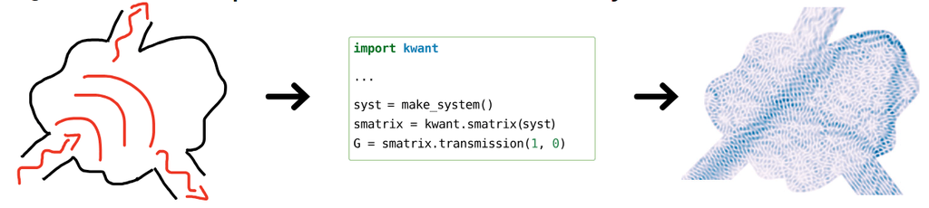

[figure not shown]

Figure from Kwant

# Can one make a roundabout for waves?

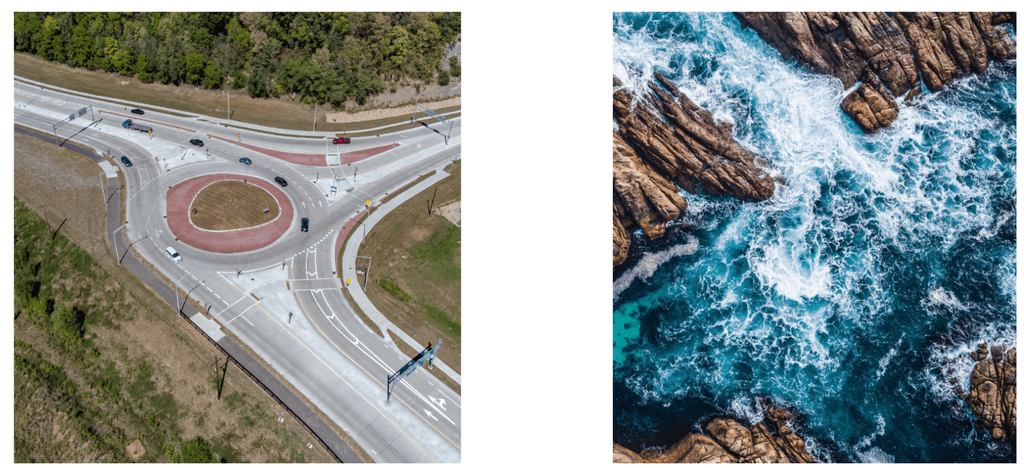

# Can one make a roundabout for waves?

### Transmission protected by smooth potential

van Wees et al. 1988

Waves scatter but transmission is still protected

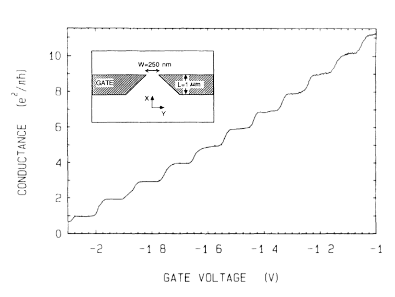

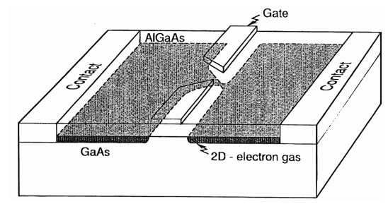

# Chiral transmission protected by topology

Klitzing et al. 1980

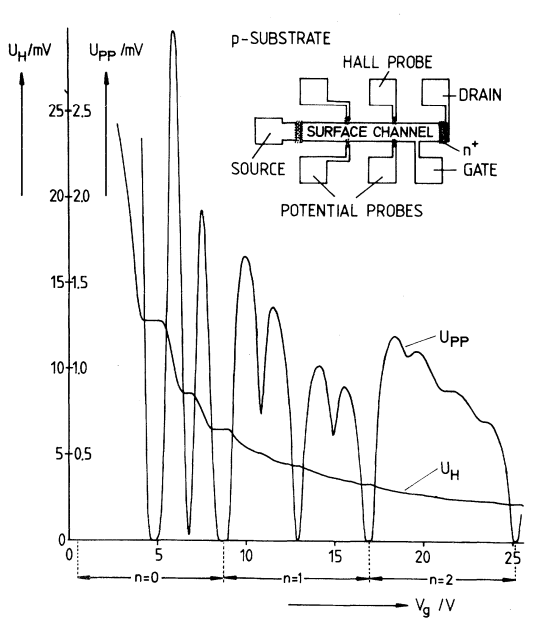

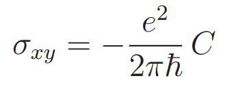

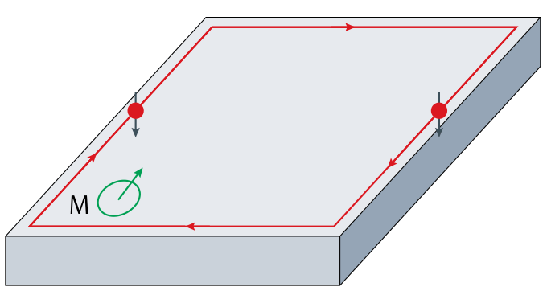

# Quantization of critical current

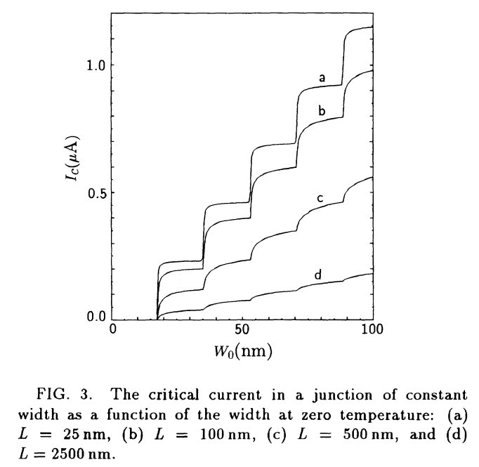

C. W. J. Beenakker et al. 1991, Akim Furusaki et al. 1991

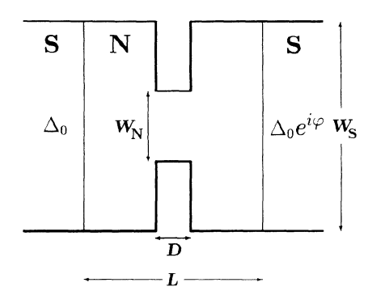

# Quantized transmission without nontrivial gap

Observations:

1. Quantized transmission between channels

2. Transmission is chiral

# Quantized transmission without nontrivial gap

**arxiv:2311.17160**

Requirements:

1. Transparent Josephson junctions

2. Short junction regime

3. Metal and superconductor share normal Hamiltonian

**arxiv:2311.17160**

W

L

W ≪ \xi_0 ≪ L

# Quantized transmission without nontrivial gap

# What protects transmission?

# What protects transmission?

# Why is it chiral?

# Building block: a Josephson Junction

Tam. et al. 2023

Nonlocal Andreev conductance in a π-junction counts Fermi surfaces

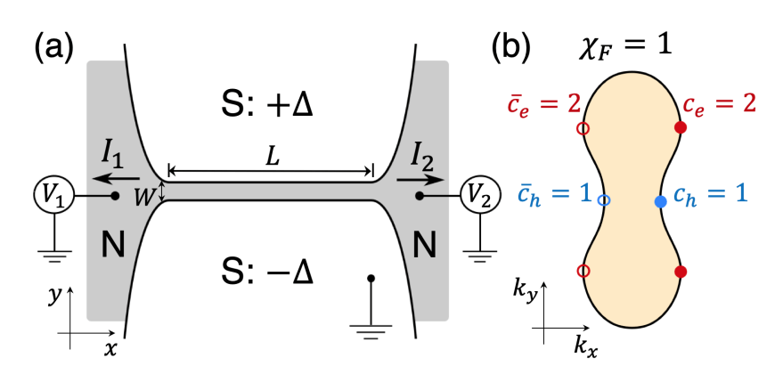

\langle I_2 \rangle = -2 \chi_F e^2 \lvert V \rvert / \pi h

# Building block: a Josephson Junction

Tam. et al. 2023

Zero modes split near critical points and acquire dispersion

# open channels = # critical points

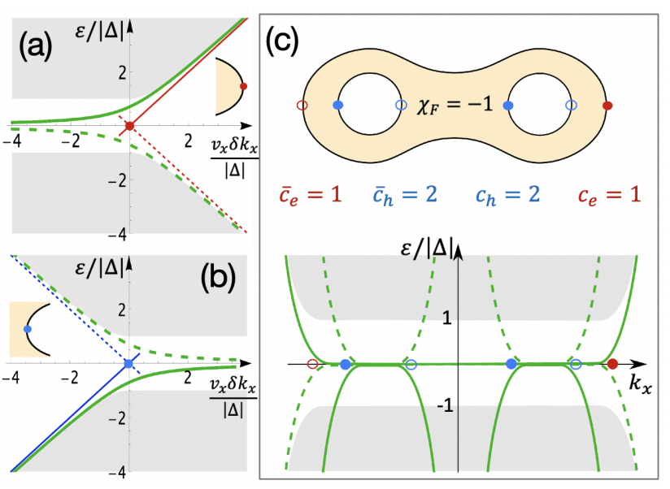

# Role of the phase difference

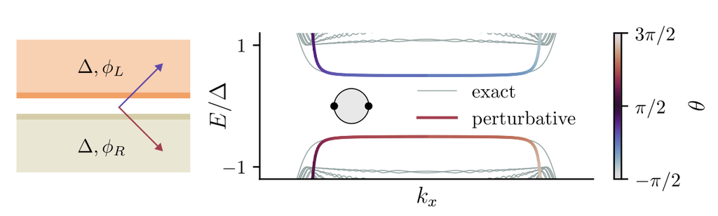

\Delta \cos(\delta \phi/2)

# How robust is this quantization?

# How robust is this quantization?

# How robust is this quantization?

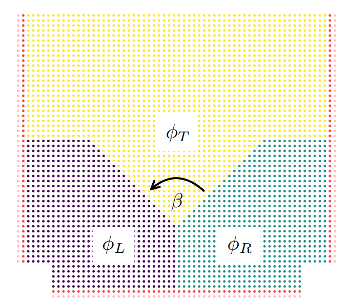

1.

2.

3.

H_{ee} \rightarrow 2 H_{ee}

Break rotation symmetry

Introduce anisotropy

Particle-hole symmetry

# Quantized chiral transmission is robust

Reflection is the only process allowed

# Quantized chiral transmission is robust

At higher energies another channel becomes available

# Quantized chiral transmission is robust

Transmission is chiral when all channels are open

# Effective energy barrier

# Effective energy barrier

States parallel to the junction are at higher energies!

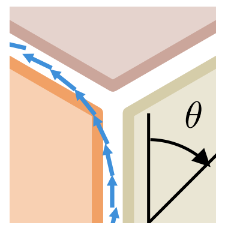

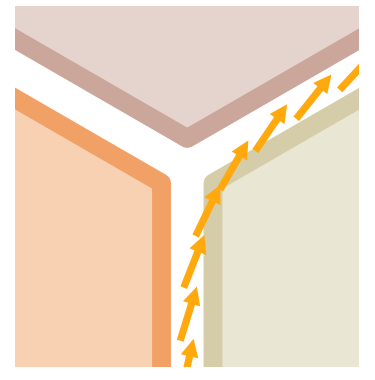

Allowed

Forbidden

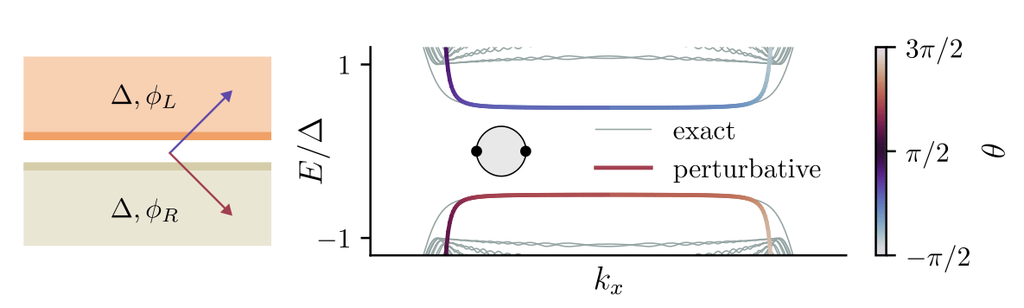

# Where to observe CAT?

# Where to observe CAT?

# Where to observe CAT?

Short ballistic Josephson junctions with smooth interfaces

Gate-defined superconductivity

Al-InAs-Al highly-transparent JJ

Zhou et al. 2022, M. Kjaergaard et al. 2017

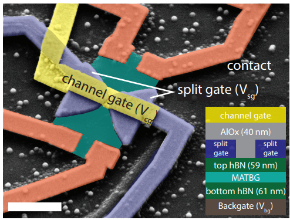

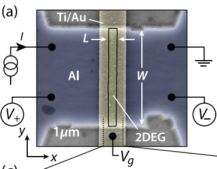

# Summary and outlook

# Summary and outlook

**arxiv:2311.17160**

1. Fermi surface topology determines protected transmission value

2. Protection is robust due to momentum space separation of wavefunctions

3. Hard to observe in real superconductors, but possible in metamaterials